# HW L4 R

Dr MM Hasan

2025-05-10

## Homework Lecture 04 on R

Q1. **(Factor vs Character) Explain the difference between a character vector and a factor in R. Why would mutation_status be a factor and not just a character vector?**

Ans: Chartres vector is a vector that contains text strings, e.g. “Red”, “Blue”. While the factor is a categorical vector/variable in R representing data with a fixed set of values, known as levels.In factors we can sort data or arrange in different categories if needed.

Q2. **(Factor Level Order) You observed the following bacterial species in gut microbiome samples:**

```r
species <- c("Lactobacillus", "Bacteroides", "Escherichia", "Bacteroides", "Lactobacillus")
species_factor <- factor(species, levels = c("Bacteroides", "Escherichia", "Lactobacillus"))
```

What will levels(species_factor) return? Why?

```r
levels(species_factor)
```

```
## [1] "Bacteroides"   "Escherichia"   "Lactobacillus"
```

*Why?* ANS:We are seeing the orders of the text strings as we defines using `levels` argument.

Q3. **Given the factor:**

```r
disease_severity <- factor(c("Mild", "Severe", "Moderate"), levels = c("Mild", "Moderate", "Severe", "Critical"), ordered = TRUE)
```

What will be the result of `disease_severity[1] < disease_severity[2]` and why?

```r
disease_severity[1] < disease_severity[2]
```

```
## [1] TRUE
```

*we are seeing `TRUE` and the reason is we determined the order of `Severe` as higher order than the `Mild` one, so the the logical argument here is returned `TRUE`.

Q4. **You computed:**

```r
prop <- prop.table(table(species_factor))
```

We can simply deterrmine the proportion of Escherichia by `prop["Escehricia"]`;

```r
prop["Escherichia"]
```

```
## Escherichia
##         0.2
```

or by using the order we used in `levels`, which was 2

```r
prop[2]
```

```
## Escherichia
##         0.2
```

**Is prop$Escherichia Valid?** NO

```r
#prop$Escherichia
```

**Reason**: $ operator is used to access elements of a list or data frame, but here `prop` is an atomic vector, we need to use [] for accessing its elements.

Q5. **Interpret what this query returns:**

The data frame is:

```r
# Create a data frame
gene_df <- data.frame(
  gene_id = c("BRCA1", "TP53", "MYC", "EGFR", "GAPDH"),
  expression = c(8.2, 6.1, 9.5, 7.0, 10.0),
  mutation = factor(c("Yes", "No", "Yes", "No", "No")),
  pathway = c("DNA Repair", "Apoptosis", "Cell Cycle", "Signaling", "Metabolism")
)

gene_df
```

```
##   gene_id expression mutation    pathway
## 1   BRCA1        8.2      Yes DNA Repair
## 2    TP53        6.1       No  Apoptosis
## 3     MYC        9.5      Yes Cell Cycle
## 4    EGFR        7.0       No  Signaling
## 5   GAPDH       10.0       No Metabolism
```

If we run tye provided code, we will get

```r
gene_df[gene_df$expression > 7 & gene_df$mutation == "No", ]
```

```
##   gene_id expression mutation    pathway
## 5   GAPDH         10       No Metabolism
```

*Explanations:* this filtering can keep the data where the expression level is higher than 7 and also there is no mutation.

Q6. **You have:**

```r
samples <- c("WT", "KO", "WT", "KO", "WT")
expression <- c(5.2, 8.1, 4.3, 9.0, 5.7)
```

Dataframe:

```r
df <- data.frame(
  samples = samples,
  expression = expression
)

df
```

```
##   samples expression
## 1      WT        5.2
## 2      KO        8.1
## 3      WT        4.3
## 4      KO        9.0
## 5      WT        5.7
```

1. *Create a factor `group_factor` for the samples.*

```r
group_factor <- factor(samples)
group_factor
```

```
## [1] WT KO WT KO WT
## Levels: KO WT
```

2. *Use `tapply()` to calculate mean expression per group.*

```r
mean_expression <- tapply(expression, group_factor, mean)
#print mean values
mean_expression
```

```
##       KO       WT
## 8.550000 5.066667
```

3. *Plot a `barplot` of average expression for each group.*

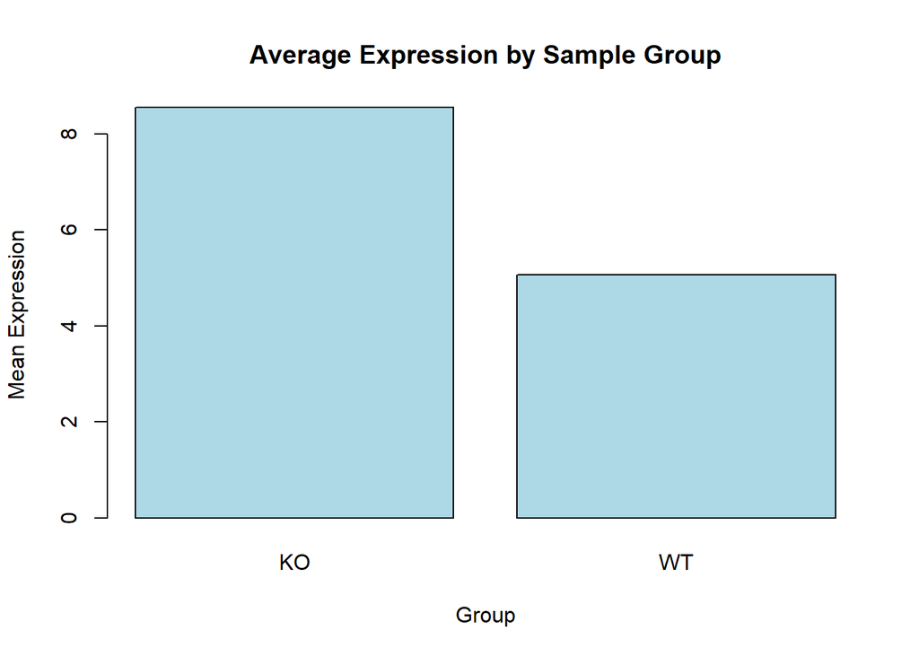

```r
barplot(mean_expression,
        main = "Average Expression by Sample Group",
        xlab = "Group",
        ylab = "Mean Expression",
        col = "lightblue")
```

Q7. **Use the gene_df example. Subset the data to find genes with:**

*expression > 8*

*pathway is either “Cell Cycle” or “Signaling”*

```r
subset_gene_df <- gene_df[gene_df$expression > 8 & gene_df$pathway %in% c("Cell Cycle", "Signaling"), ]



#print subset data

subset_gene_df
```

```
##   gene_id expression mutation    pathway
## 3     MYC        9.5      Yes Cell Cycle
```

Q8. **Create an ordered factor for the disease stages: `c("Stage I", "Stage III", "Stage II", "Stage IV", "Stage I")`. Then plot the number of patients per stage using `barplot()`. Confirm that `"Stage III" > "Stage I"` is logical in your factor.**

```r
can_stage <- c("Stage I", "Stage III", "Stage II", "Stage IV", "Stage I")
can_stage_factor <- factor(can_stage, levels = c("Stage I", "Stage II", "Stage III", "Stage IV"), ordered = TRUE)
#print can_stage_factor
can_stage_factor
```

```
## [1] Stage I   Stage III Stage II  Stage IV  Stage I
## Levels: Stage I < Stage II < Stage III < Stage IV
```

```r
can_stage_factor[5] < can_stage_factor [2]
```

```
## [1] TRUE
```

```r
freq <- table(can_stage_factor)

freq
```

```
## can_stage_factor
##   Stage I  Stage II Stage III  Stage IV
##         2         1         1         1
```

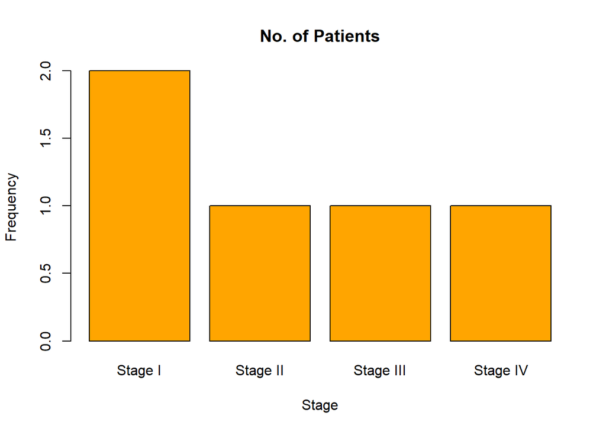

```r
barplot(freq,
        main = "No. of Patients",
        xlab = "Stage",
        ylab = "Frequency",
        col = "orange")
```

Q9. **Suppose gene_data has a column type with values “Oncogene”, “Tumor Suppressor”, and “Housekeeping”.**

*Subset all “Oncogene” rows where expression > 8.*

```r
gene_df$gene_data <- factor(c("Tumor Suppressor", "Tumor Suppressor", "Oncogene", "Oncogene", "Housekeeping"))


gene_df
```

```
##   gene_id expression mutation    pathway        gene_data
## 1   BRCA1        8.2      Yes DNA Repair Tumor Suppressor
## 2    TP53        6.1       No  Apoptosis Tumor Suppressor
## 3     MYC        9.5      Yes Cell Cycle         Oncogene
## 4    EGFR        7.0       No  Signaling         Oncogene
## 5   GAPDH       10.0       No Metabolism     Housekeeping
```

```r
oncogene_subset <- gene_df[gene_df$gene_data == "Oncogene" & gene_df$expression > 8, ]

#oncogene_subset
oncogene_subset
```

```
##   gene_id expression mutation    pathway gene_data
## 3     MYC        9.5      Yes Cell Cycle  Oncogene
```

*Change the reference level of the factor type to “Housekeeping”* Ans:

```r
levels(gene_df$gene_data)
```

```
## [1] "Housekeeping"     "Oncogene"         "Tumor Suppressor"
```

As we are seeing “Housekeeping” at the beginning by default ordering I think that should be counted as Reference, If I am not get the context wrong!

Q10.**Simulate expression data for 3 tissues: We are going to use rnorm() function to generate random values from a normal distribution for this purpose. The example values inside the rnorm() function means we want:**

- 30 values in total,
- average or mean value = 8,
- standard deviation of expression is 2.

Provided code:

```r
set.seed(42) # For reproducibility
gene_expr <- rnorm(30, mean = 8, sd = 2)
tissue <- rep(c("brain", "liver", "kidney"), each = 10)
tissue_factor <- factor(tissue, levels = c("liver", "brain", "kidney"))

tissue_factor
```

```
##  [1] brain  brain  brain  brain  brain  brain  brain  brain  brain  brain
## [11] liver  liver  liver  liver  liver  liver  liver  liver  liver  liver
## [21] kidney kidney kidney kidney kidney kidney kidney kidney kidney kidney
## Levels: liver brain kidney
```

```r
expr_data <- data.frame(
  tissue = tissue_factor,
  expression = gene_expr
)

#expr_data
head(expr_data)
```

```
##   tissue expression
## 1  brain  10.741917
## 2  brain   6.870604
## 3  brain   8.726257
## 4  brain   9.265725
## 5  brain   8.808537
## 6  brain   7.787751
```

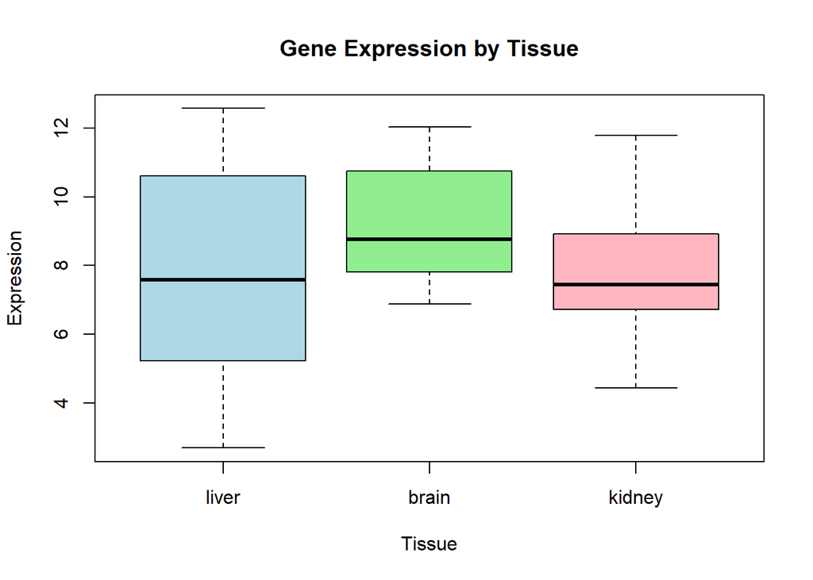

```r
boxplot(expression ~ tissue,
        data = expr_data,
        main = "Gene Expression by Tissue",
        xlab = "Tissue",
        ylab = "Expression",
        col = c("lightblue", "lightgreen", "lightpink"))
```

```r
sd_expression <- tapply(expr_data$expression, expr_data$tissue, sd)
sd_expression
```

```
##    liver    brain   kidney
## 3.261169 1.670898 2.312116
```

```r
max_sd_tissue <- names(sd_expression)[which.max(sd_expression)]
max_sd_value <- sd_expression[which.max(sd_expression)]
cat("The tissue with the highest sd is:", max_sd_tissue,", with SD =", round(max_sd_value, 2), "\n")
```

```
## The tissue with the highest sd is: liver , with SD = 3.26
```